# Reproducible Research: Peer Assessment 1

## Loading and preprocessing the data

We are loading **data.table** for fast data handling and **ggplot2**. Also we change system time display to English by **Sys.setlocale**.

```r
Sys.setlocale("LC_TIME", "English")
library(data.table)
library(ggplot2)
```

The function for interval to handy time format is being created.  
It converts 5-time intervals to hour:mi POSIXlt.

```r
int2nicetime <- function(nc) {
      nice_time <- nc
      nice_time <- lapply(nice_time, toString)
      nice_time[nchar(nice_time)<3] <- paste("00", nice_time[nchar(nice_time)<3], sep = "")
      nice_time[nchar(nice_time)<4] <- paste("0", nice_time[nchar(nice_time)<4], sep = "")
      nice_time_left <- substr(nice_time,1,2)
      nice_time_right <- substr(nice_time,3,4)
      nice_time <- paste(nice_time_left, ":", nice_time_right, sep="")
      as.POSIXct(nice_time, origin = as.POSIXct(
                strptime("1970-01-01 00:00:00", "%Y-%m-%d %H:%M:%S", tz="Europe/Moscow")), format="%H:%M")

}
```

Loading the data and getting rid of NA values.

```r
unzip("activity.zip")
activity_raw <- data.table(read.csv("activity.csv"))
activity_raw_tidy <- activity_raw[complete.cases(activity_raw$steps),]
dir.create("figures")
```

## What is mean total number of steps taken per day?

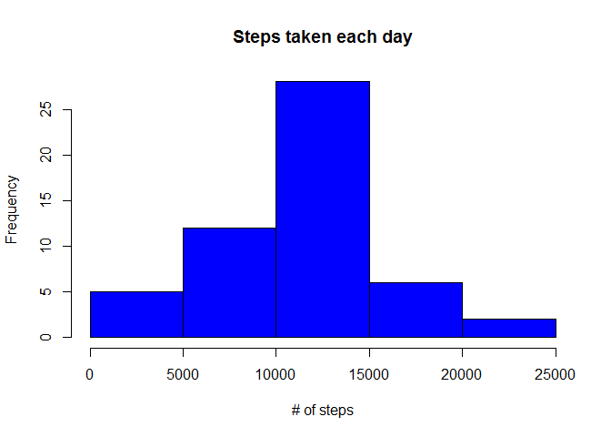

```r
activity_sum_bydate <- activity_raw_tidy[,lapply(.SD, sum), by = "date"]
activity_sum_bydate <- activity_sum_bydate[, interval:=NULL]
par(mfrow = c(1,1))
hist(activity_sum_bydate$steps, col = "blue", xlab = "# of steps",
     main = "Steps taken each day", bty = "l")
```

```r
dev.off()
mean_steps <- mean(activity_sum_bydate$steps)
median_steps <- median(activity_sum_bydate$steps)
```

Mean of steps: 10766.19  
Median of steps: 10765  
Looks like ther step distribution is almost symmetric

## What is the average daily activity pattern?

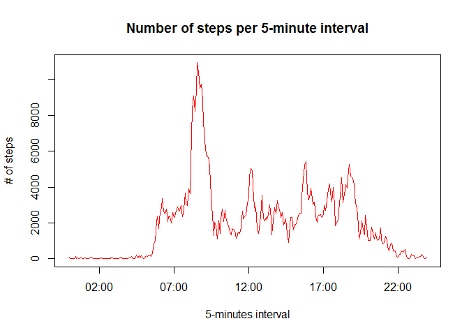

```r
activity_sum_byint <- activity_raw_tidy[,lapply(.SD, sum), by = "interval"]
activity_sum_byint <- activity_sum_byint[, date:=NULL]
par(mfrow = c(1,1))
#png(filename = "figures/stepsbyint_tsplot.png", width = 480, height = 480)
plot(int2nicetime(activity_sum_byint$interval), activity_sum_byint$steps, type = "l", col = "red", xlab = "5-minutes interval", ylab = "# of steps", main = "Number of steps per 5-minute interval")
```

```r
dev.off()
max_int <- activity_sum_byint$interval[activity_sum_byint$steps == (max(activity_sum_byint$steps))]
```

Interval with maximum average step value: 835

## Imputing missing values

We are replacing NA with mean valuee of steps for interval based on weekday.

```r
sum_na_steps <- sum(is.na(activity_raw$steps))
weekdays_tidy <-  weekdays(as.POSIXlt(activity_raw_tidy$date))

activity_raw_tidy_w <- activity_raw_tidy[, weekday := weekdays_tidy]
activity_mean_byintweek <- activity_raw_tidy_w[,lapply(.SD, mean), by = "weekday,interval"]
activity_mean_byintweek <- activity_mean_byintweek[, date := NULL]
```

Replacing NA steps with mean by interval and weekday

```r
weekdays <-  weekdays(as.POSIXlt(activity_raw$date))
activity_na_rep <- activity_raw[, weekday := weekdays]

for (i in 1:length(activity_na_rep$steps)) {
  if (is.na(activity_na_rep$steps[i])){
    activity_na_rep$steps[i] <-
      activity_mean_byintweek$steps[activity_na_rep$interval[i]==activity_mean_byintweek$interval &
                                          activity_na_rep$weekday[i]==activity_mean_byintweek$weekday]
  }
}
```

Repeating task 1 for the data.

```r
activity_nar_sum_bydate <- activity_na_rep
activity_nar_sum_bydate <- activity_nar_sum_bydate[,weekdaytype:=NULL]
activity_nar_sum_bydate <- activity_nar_sum_bydate[,weekday:=NULL]
activity_nar_sum_bydate <-activity_nar_sum_bydate[,lapply(.SD, sum), by = "date"]
```

Calculcating task 1 for replaced NA data

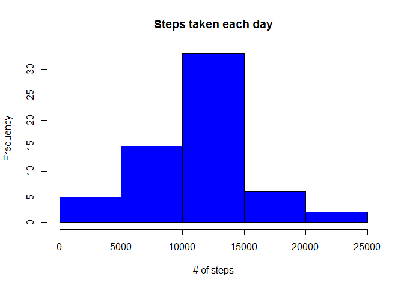

```r
activity_nar_sum_bydate <- activity_nar_sum_bydate[, interval:=NULL]
par(mfrow = c(1,1))
hist(activity_nar_sum_bydate$steps, col = "blue", xlab = "# of steps",
     main = "Steps taken each day", bty = "l")
```

```r
dev.off()
#mean and median for replaced
mean_steps_nar <- mean(activity_nar_sum_bydate$steps)
median_steps_nar <- median(activity_nar_sum_bydate$steps)
```

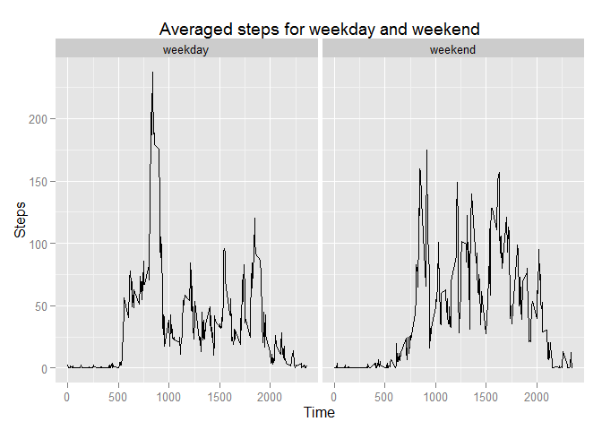

```r
activity_na_rep <- activity_na_rep[, weekday := weekdays]
activity_na_rep$weekdaytype <- 0
activity_na_rep$weekdaytype[!grepl("^S",activity_na_rep$weekday)] <- "weekday"
activity_na_rep$weekdaytype[grepl("^S",activity_na_rep$weekday)] <- "weekend"
activity_mean_byint_wtype <- activity_na_rep[,date:=NULL]
activity_mean_byint_wtype <- activity_mean_byint_wtype[,weekday:=NULL]
activity_mean_byint_wtype <- activity_mean_byint_wtype[,lapply(.SD, mean), by = "interval,weekdaytype"]

g <- ggplot(activity_mean_byint_wtype, aes(interval, steps))
p <- g + geom_line() + facet_wrap( ~ weekdaytype) +
  labs(title = "Averaged steps for weekday and weekend") +
  labs(y = "Steps", x = "Time")
print(p)
```

```r
dev.off()
```

Looks like during weekdays morning activity is higher comparing weekdays.